# Assignment 3 Task 2

Sarah Lam

11/4/2021

# 1. Overview

# 2. Data and Analyses

“Bonanza Creek LTER is part of the US Long Term Ecological Research Network. See more information about the site here. In this “mini exploratory report,” you will explore the counts and sizes of juvenile snowshoe hares recorded from 1998 - 2012. The data citation and link to metadata (including variable definitions) are below."

Kielland, K., F.S. Chapin, R.W. Ruess, and Bonanza Creek LTER. 2017. Snowshoe hare physical data in Bonanza Creek Experimental Forest: 1999-Present ver 22. Environmental Data Initiative. https://doi.org/10.6073/pasta/03dce4856d79b91557d8e6ce2cbcdc14

```r
hares <- read_csv(here("data", "bonanza_hares.csv"))
```

# 3. Preliminary Results

## A. Juvenile hare trapping data

Annual juvenile hare trap counts. Count the total number of juvenile hare trappings during each year of the study, and create a finalized data visualization of the counts by year. Include a figure caption below the figure in your report.

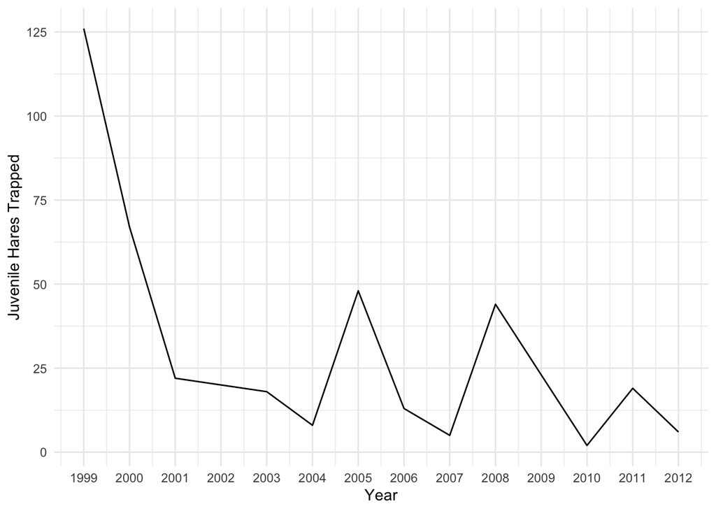

```r
juvenile_traps <- hares %>%
  filter(age == "j") %>%
  mutate(date_class = mdy(date)) %>%
  mutate(year = year(date_class)) %>%
  group_by(year) %>%
  summarize(count = n())

ggplot(data = juvenile_traps, aes(x = year, y = count)) +
  geom_line() +
  scale_x_continuous(breaks = 1999:2012) +
  theme_minimal() +
  labs(x = "Year",
       y = "Juvenile Hares Trapped")
```

Then, in 3 - 4 sentences below your figure, describe major takeaways from your graph about total snowshoe hare trappings at the site. You might consider:

What were the minimum and maximum counts of juvenile hare trappings? Mean or median annual number of juvenile hares trapped? General/notable trends? These are absolute counts, but this count is also impacted by effort (e.g. the number of days and number of traps in the study each year). What would you suggest be done moving forward (you are not expected to actually do this) to standardize the juvenile hare population in future analyses?